# Final Assignment Practical Machine Learning

Tim Menkveld

10/26/2020

Please note that my personal learning objetive is to learn TidyModels Learn more about tidymodels on tidymodels.com or tmwr.org (or Google Julia Silge and her YouTube channel!)

### TASK / DESCRIPTION

Six young health participants were asked to perform one set of 10 repetitions of the Unilateral Dumbbell Biceps Curl in five different fashions: exactly according to the specification (Class A), throwing the elbows to the front (Class B), lifting the dumbbell only halfway (Class C), lowering the dumbbell only halfway (Class D) and throwing the hips to the front (Class E).

Class A corresponds to the specified execution of the exercise, while the other 4 classes correspond to common mistakes. Participants were supervised by an experienced weight lifter to make sure the execution complied to the manner they were supposed to simulate. The exercises were performed by six male participants aged between 20-28 years, with little weight lifting experience. We made sure that all participants could easily simulate the mistakes in a safe and controlled manner by using a relatively light dumbbell (1.25kg).

Read more: http://groupware.les.inf.puc-rio.br/har#ixzz6btOsq0kc

There are 160 variables and 19k rows. About equal distribution of our dependent variable ‘classe’, but would make sense to control for this when splitting the data.

Column type frequency:  
- factor 37  
- numeric 123 - A: 5580, B: 3797, E: 3607, C: 3422

some variables only occur ~2% of times in the dataset. I exlcude these variables and when new_window = yes.

For each model, we apply the predictions to the TEST data. So the accuracy, ROC_AUC score and confusion matrices are all performed on the test set. This means that, if a score of 70% is achieved in terms of accuracy on the test set, this model achieves this performance on out of sample data, i.e. a 30% out of sample error.

We end up with about 50 numeric variables, and only for rows where the new_window = ‘no’.

### Data split

We use rsample to split the data into train and test, and build cross validation set on the train data.

```r
# We split the data (using rsample)
init_split <- initial_split(prop = 0.75, strata = classe, data = df)
train <- training(init_split)
test <- testing(init_split)

# We will use cross validation for the decision tree to improve generalizability. We include strata = classe to control for the amount of classes per group.
cv_folds <- vfold_cv(train, strata = classe)
```

### SETUP UP PROJECT:

- We will start with a simple model: Decision Tree. Trained on the TRAIN dataset
- We will develop a Multinomial Logistic Regression and tune it’s penalty parameters, trained on crossvalidation set.
- Finally we will develop a random forest model, trained on crossvalidation set.
- For each model, the code for how it’s trained will be in the appendix to safe some space in the report.

### Decision Tree

#### We build a model, but the code is not included. The results are shown below!

```r
#Let's look at it's performance!
test_pred_decision_tree %>% collect_metrics()
```

| .metric | .estimator | .estimate |
| --- | --- | --- |
| accuracy | multiclass | 0.7428155 |
| roc_auc | hand_till | 0.9055874 |

```r
test_pred_decision_tree %>%
  unnest(.predictions) %>%
  conf_mat(classe, .pred_class)
```

```
##           Truth
## Prediction    A    B    C    D    E
##          A 1209  138   22   49   12
##          B   42  546   40   58   57
##          C   34  105  670  122  110
##          D   61   69   52  495   56
##          E   21   71   54   62  647
```

We see that the model is not bad at identifying which classe it belongs to!

### 2.Multinomial Logistic Regression

Let’s tune a multinomial logistic regression model with generalization/penalty We have a to add a few steps to, to indicate which parameters we want tuned and with which settings.

#### We build a multinominal logistic regression with penalty, but the code is not included. The results of the tuning are shown below!

We plot the different performance of the different settings, the higher the mean (representing roc_auc score), the better (instead of roc_auc, we can plot accuracy).

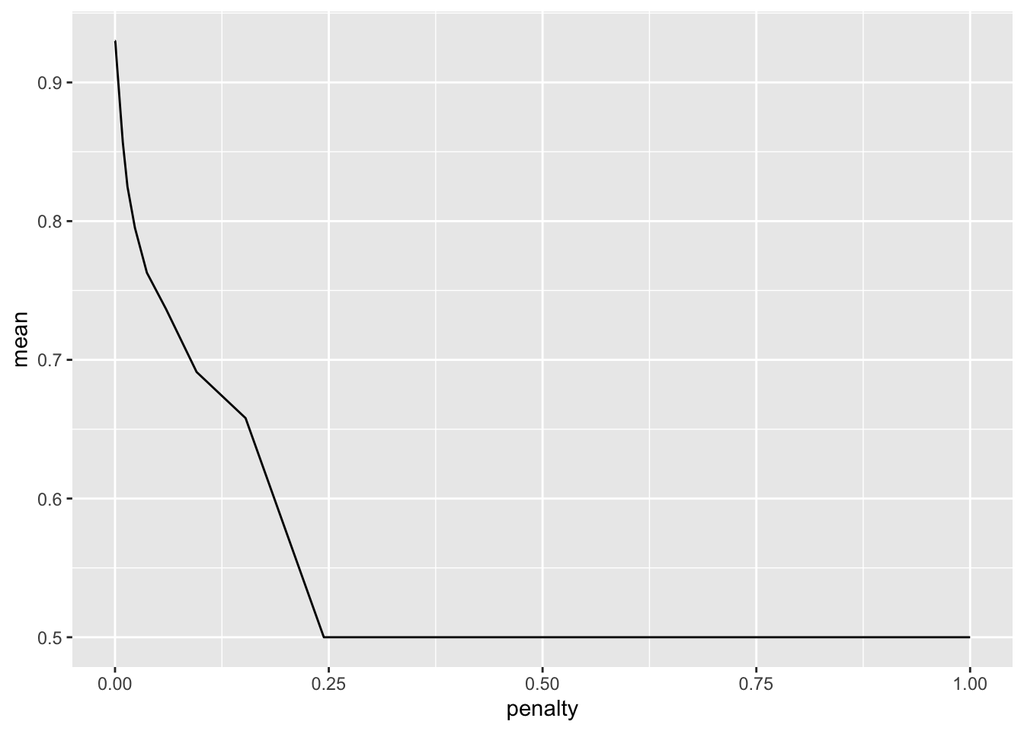

```r
multinom_results %>%
  collect_metrics() %>%
  filter(.metric == 'roc_auc') %>%
  ggplot(aes(x = penalty, y = mean)) + geom_line()
```

We see that the performance drops quickly! we can use ‘select_best’ to pick the best setting for us so we won’t exactly derive the best penalty score from this graph.

```r
#How does this model perform on TEST data?
tuned_final_multinom_reg %>% collect_metrics()
```

| .metric | .estimator | .estimate |
| --- | --- | --- |
| accuracy | multiclass | 0.7365681 |
| roc_auc | hand_till | 0.9294205 |

```r
#tuned_final_multinom_reg %>% collect_predictions()  # call this to get the predicitons
tuned_final_multinom_reg %>%
  unnest(.predictions) %>%
  conf_mat(classe, .pred_class)
```

```
##           Truth
## Prediction    A    B    C    D    E
##          A 1177  118   71   64   43
##          B   39  613   82   37   95
##          C   79   85  601   98   57
##          D   61   36   56  542   83
##          E   11   77   28   45  604
```

We see that the model has improved on some classe’s over the last, but does worse on some others.

### Random Forest

#### We build a random forest, code is not included here for the build, but we show the tuning step and final performance.

#### Tuning performance

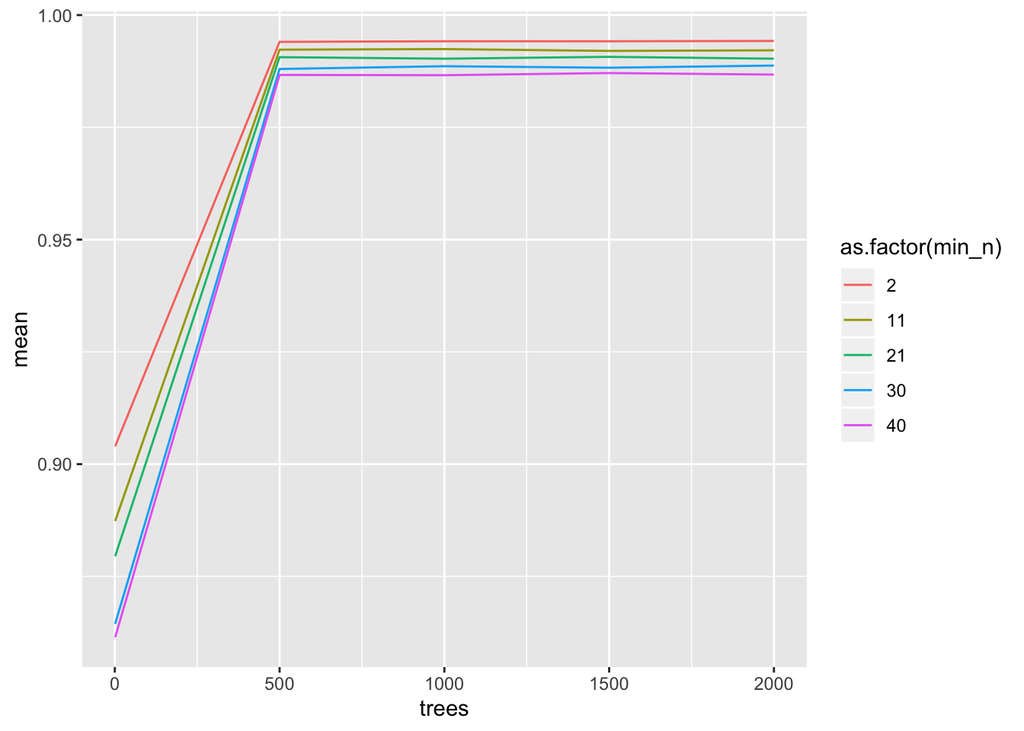

```r
#Plot results of the different trees
tree_res %>%
  collect_metrics() %>%
  filter(.metric == 'accuracy') %>%
  ggplot(aes(x = trees, y = mean  , group = min_n, color = as.factor(min_n))) + geom_line()
```

```r
# We see that the performance peaks at 500 trees and at min_n of 2
```

#### Final performance

```r
#How does this model perform on TEST data?
tuned_final_res %>% collect_metrics()
```

| .metric | .estimator | .estimate |
| --- | --- | --- |
| accuracy | multiclass | 0.9947938 |
| roc_auc | hand_till | 0.9999441 |

```r
# How does this model perform as shown by confusion matrix
tuned_final_res %>%
  unnest(.predictions) %>%
  conf_mat(classe, .pred_class)
```

```
##           Truth
## Prediction    A    B    C    D    E
##          A 1366    7    0    0    0
##          B    1  922    3    0    0
##          C    0    0  834    9    0
##          D    0    0    1  775    2
##          E    0    0    0    2  880
```

It’s performing too good to be true. The out of sample error is super small. I’m afraid of data leakage.. but as I use the same variables in the other models this shouldn’t be possible. To be sure, I want to check the variable importance. And I see indeed, that there is NOT one variable with all/most importancel.

#### Variable Importance

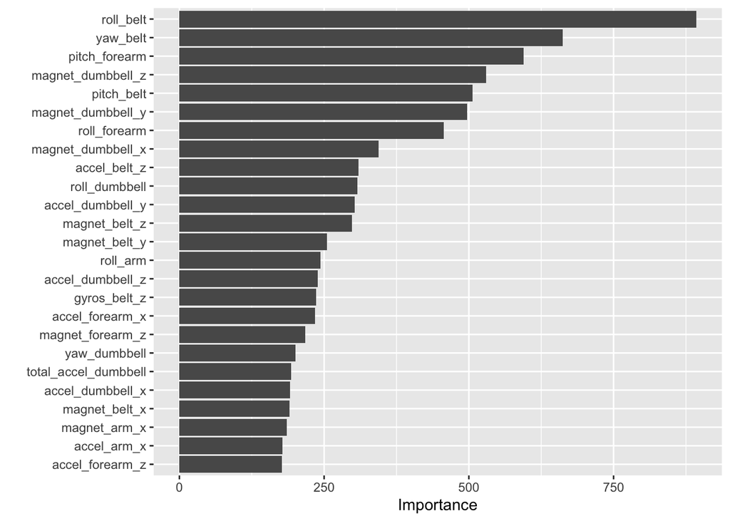

```r
tuned_final_wf %>%
  fit(train) %>%
  pull_workflow_fit() %>%
  vip(geom = "col",
      num_features = 25)
```